# Regressão Linear

Walter Humberto Subiza Pina

1 de março 2019

## Regressão Linear

A regressão linear é usada quando queremos predecir o valor de uma variável *Y*, chamada de resposta, baseado em uma ou mais variáveis preditores ou explicativas, denominadas *Xs*.

O objetivo é estabelecer uma relação matematica linear através de uma fórmula, que relacione a(s) variáveis explicativas e a variável resposta, de forma que, quando os valores das variáveis explicativas são conhecidas, é possível estimar o valor da variável resposta.

#### Introdução

O objetivo exposto acima, pode ser generalizado através da seguinte equação:

$$Y= β_1 + β_2 X + ϵ$$

onde, $β_1$ é o intercepto, ou ponto de cruzamento da reta de regressão com o eixo *Y* e $β_2$ é o coeficiente angular da inclinação da reta em relação ao eixo *X*.

Os dois coeficientes juntos são chamados de **coeficientes de regressâo**. Finalmente, *ϵ* é o termo de erro que o modelo é incapaz de explicar.

#### Análise gráfico

Antes de começar o cálculo da regressão, é de boa prática analisar e entender o comportamento das nossas variáveis. O análise gráfico e um estudo de correlação vai ajudar nesse processo.

O exercício consiste em construir um modelo simples de regressão, que possa ser usado para calcular uma distância a percorrer, a partir da relação linear da distância com a velocidade (variáveis “dist” e “speed”, respectivamente, ambas conhecidas).

Normalmente usam-se três ferramentas para entender e visualisar o comportamento das variáveis, que são:

1- **Gráfico de dispersão**, permite visualizar a relação entre as variáveis explicativas e resposta

2- **Gráfico das 5 medidas ou Box-plot**, permite identificar valores discrepantes en uma variável. Valores discrepantes ou extremos podem afetar significativamente a magnitude ou direção da linha de melhor ajuste.

3- **Gráfico de densidade**, para analisar a variável explicativa, idealmente deveria ter uma distribuição perto da normal, sem desvios a direita ou esquerda (assimetrias ou *skew*).

Vejamos cada uma delas:

##### Gráfico de dispersão

Ajudam a visualizar a relação entre a variável explicativa e a resposta. Se tiver mais de uma variável explicativa, deve ser feito um gráfico para cada uma em forma independente, incluíndo a linha de melhor ajuste.

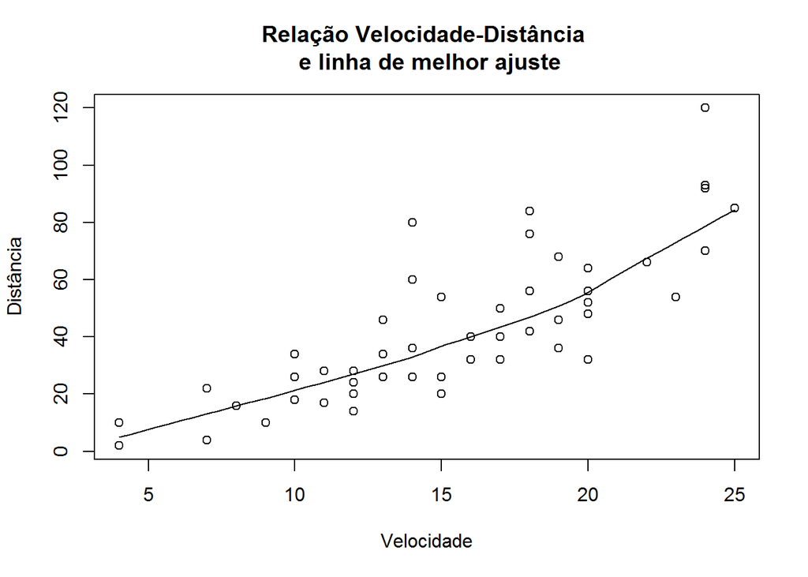

```r
scatter.smooth(cars$speed, cars$dist,
               main="Relação Velocidade-Distância \n e linha de melhor ajuste",
               xlab = "Velocidade",
               ylab = "Distância")
```

O gráfico sugere que existe uma relação linear crescente entre a velocidade e distância. Isto é um bom sinal já que um dos supostos em regressão linear é que existe uma relação linear e aditiva entre as variáveis explicativas e a resposta.

##### Gráfico dos 5 números ou *box-plot*

Qualquer observação que exceda uma vez e meia a amplitude inter-quartílica, ou seja ($1,5 * (Q3-Q1)$), é considerado um valor discrepante ou extremo (outlier). $Q3$ e $Q1$ são os 75 e 25 valores de percentís da variável considerada.

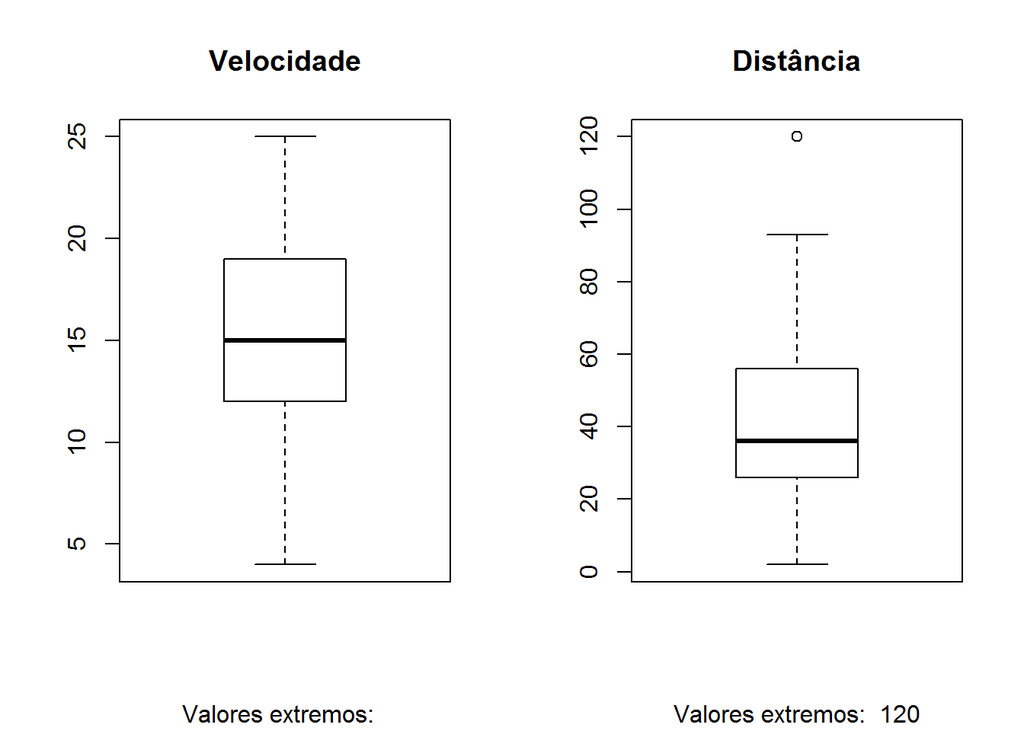

```r
par(mfrow=c(1, 2))  # dividir o espaço em duas colunas

boxplot(cars$speed,
        main="Velocidade",
        sub=paste("Valores extremos: ",
                  boxplot.stats(cars$speed)$out))

boxplot(cars$dist,
        main="Distância",
        sub=paste("Valores extremos: ",
                  boxplot.stats(cars$dist)$out))
```

Como se aprecia, apenas o valor de 120 na variável “dist” aparenta ser um valor extremo, no caso da variável “speed” não apresenta nenhum valor fora do AIQ.

##### Gráfico de densidade

O gráfico ajuda a verificar a normalidade da distribuição de cada variável.

```r
library(e1071)
```

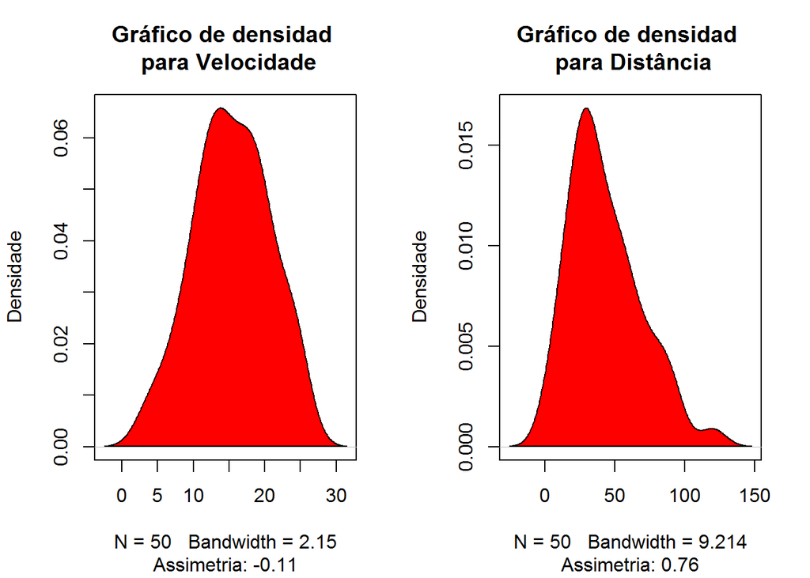

```r
par(mfrow=c(1, 2))  # divide a área para dois gráficos separados
# primeiro grafico com Velocidade
plot(density(cars$speed),
     main="Gráfico de densidad \n para Velocidade",
     ylab="Densidade",
     sub=paste("Assimetria:",
               round(e1071::skewness(cars$speed), 2)))  # density plot for 'speed'
polygon(density(cars$speed), col="red")

plot(density(cars$dist),
     main="Gráfico de densidad \n para Distância",
     ylab="Densidade",
     sub=paste("Assimetria:",
               round(e1071::skewness(cars$dist), 2)))  # density plot for 'dist'
polygon(density(cars$dist), col="red")
```

No caso da velocidade, nota-se que a curva de densidade é muito próxima da normal, enquando a de distância apresenta uma leve assimetria à direita. A presença do outlier de 120 é visível.

#### Construindo um modelo linear

Uma vez analisada gráficamente e numéricamente a relação entre as variáveis, vamos ver ver como se calcula o modelo linear de regressão. A função usada é **lm()** que tem dois argumentos de entrada, o primeiro sendo a fórmula de cálculo e o segundo os dados. Os dados são normalmente um dataframe e a fórmula é um objeto de classe fórmula do **R** , ainda que seja comum escrever a fórmula diretamente como no exemplo a seguir:

```r
modelo_linear <- lm(dist ~ speed, data=cars)  # argumentos: fórmula, dados
print(modelo_linear)
```

```
##
## Call:
## lm(formula = dist ~ speed, data = cars)
##
## Coefficients:
## (Intercept)        speed
##     -17.579        3.932
```

O modelo linear calculado, estabelece a relação entre o preditor e a reposta, na forma de uma fórmula matemática. Os coeficientes, como vemos acima, tem o intercepto: -17.579, e o coeficiente da velocidade: +3.932

Em outras palavras:

$distância = Intercepto + (β ∗ velocidade)$ ===> $distância = −17.579 + 3.932 ∗ velocidade$

#### Análise da Regressão Linear

Agora que temos um modelo para calcular os valores da distância, sabendo a velocidade, será que podemos usar o modelo? A resposta é **não!**.

Antes de liberar o seu uso devemos garantir que es estatísticamente significativo, para isso vamos ver algumas estatistísticas de qualidade.

```r
summary(modelo_linear)
```

```
##
## Call:
## lm(formula = dist ~ speed, data = cars)
##
## Residuals:
##     Min      1Q  Median      3Q     Max
## -29.069  -9.525  -2.272   9.215  43.201
##
## Coefficients:
##             Estimate Std. Error t value Pr(>|t|)
## (Intercept) -17.5791     6.7584  -2.601   0.0123 *
## speed         3.9324     0.4155   9.464 1.49e-12 ***
## ---
## Signif. codes:  0 '***' 0.001 '**' 0.01 '*' 0.05 '.' 0.1 ' ' 1
##
## Residual standard error: 15.38 on 48 degrees of freedom
## Multiple R-squared:  0.6511, Adjusted R-squared:  0.6438
## F-statistic: 89.57 on 1 and 48 DF,  p-value: 1.49e-12
```

##### O valor p: verificando a significancia estatística do modelo.

O resumo acima tem várias informações de importância. A primeira é o valor *p* do modelo (na última linha) e o valor *p* de cada coeficiente calculado (coluna à direita embaixo de ‘Coefficients’).

Os valores de *p* são muito importantes, já que podemos considerar um modelo linear como estatísticamente significativo se ele é inferior a determinado valor previamente escolhido como “nivel de significancia estatística” (o nível mais usado é 0.05). Visualmente também podemos verificar a significancia pelas estrelas no final da linha, quanto mais estrelas, mais significativo é o coeficiente calculado.

**Hipótese Nula e alternativa**

Quando adotamos um valor de *p* para nossa hipótese *Nula* ou $H_0$, sempre temos uma hipótese *alternativa* $H_1$ (ou $H_a$) associada.

No caso da regresssão linear, a hipótese Nula $H_0$ é que os coeficientes das variáveis são iguais a zero (as variáveis são independentes) e a hipótese Alternativa $H_1$, é que os coeficientes não são iguais a zero, então deveria uma relação entre a(s) variável(is) explicativas e a variável resposta.

No nosso modelo podemos verificar que tanto o modelo como os coeficientes apresentam valores de *p* inferiores a 0.05, pelo que o modelo e os coeficientes calculados são significativos e além disso, podemos rejeitar a hipótese *Nula* de que não existe relação entre as variáveis explicativas e resposta, com um nível de confiança de 0.95%.

##### Valor t

Podemos interpretar o valor de *t* da seguinte forma: valores maiores de *t* indicam que é menos provável que os coeficientes não sejam zero por pura aleatoridade (e por conseguinte estivermos errado com nosso modelo). Assim sendo quando maior o valor de *t*, melhor.

##### Valor Pr(>|t|)

É a probabilidade de ter um valor de *t* tão alto ou mais que o que foi calculado quando a hipótese *Nula* é verdadeira (o coeficiente β é zero o não existe relação). Por conseguinte, se o valor de Pr(>|t|) é baixo, os coeficientes são significativos (lembre que é *probabilidade*!), se o valor é alto, os coeficientes não seriam significativos.

Qual a interpretação de toda essa informação? Quando o valor *p* é inferior ao nível de significancia desejado (< 0.05), podemos com alguma certeza, rejeitar a hipótese *Nula* que o coeficiente de β é zero.

É de muita importância que o modelo seja estatísticamente significativo antes de continuar e usá-lo para calcular ou estimar valores da variável resposta.

Como calculamos os valores de *p* e *t*?

Quando tanto os coeficientes do modelo como seus desvio padrão são conhecidos, a fórmula de cálculo é:

*t estatistico* = (coeficiente β) / Devio Padrão

Vejamos passo a passo:

```r
resumo_modelo <- summary(modelo_linear)  # captura o resumo do modelo como objeto

modelo_coef <- resumo_modelo$coefficients  # coeficientes do modelo

beta.estimado <- modelo_coef["speed", "Estimate"]  #estimado de "beta" para velocidade

desv.pad <- modelo_coef["speed", "Std. Error"]  # desvio padrão da velocidade

t_valor <- beta.estimado/desv.pad  # calculo do t estatistico

# calculo do valor de p, ver stats:TDist, pt é a distribuição da função t, com df graus de liberdade
p_valor <- 2*pt(-abs(t_valor), df=nrow(cars)-ncol(cars))

f_estatistico <- resumo_modelo$fstatistic  # f estatistico

f <- summary(modelo_linear)$fstatistic  # parametros para o modelo com  p calculado

# calculo do valor de p do modelo, ver stats:FDist
modelo_p <- pf(f[1], f[2], f[3], lower=FALSE)

t_valor
```

```
## [1] 9.46399
```

```r
p_valor
```

```
## [1] 1.489836e-12
```

```r
f_estatistico
```

```
##    value    numdf    dendf
## 89.56711  1.00000 48.00000
```

```r
modelo_p
```

```
##        value
## 1.489836e-12
```

##### $R^2$ e $\bar R^2$

O valor de R quadrado, é calculado por:

$$\ R^2 = 1- \frac{SQR}{SQT}$$

Onde *SQR* é a soma dos quadrados dos resíduos dados por $SQR = \sum_i^n ( y_i - \hat y)^2$ e *SQT* é a soma dos quadrados total, dados por $SQT = \sum_i^n (y_i- \bar y)_2$.

Aqui, $\hat y_i$ é o valor ajustado para a observação *i* e $\bar y$ é o valor médio de *Y*.

Sabemos também que a soma dos erros quadrados explicada (*SQE*), indica a diferência entre a média das observações e o valor estimado para cada observação:$SQE = \sum_i^n (\hat y_i - \bar y_i)^2$.

Assim $SQT = SQE + SQR$.

Não necessariamente devemos descartar um modelo que apresenta valores baixos de $R^2$. Merece prestar atenção ao valor de *AIC* e a precisão dos valores calculados na amostra para decidir acerca da acurácia do modelo.

Em referência ao $\bar R^2$: na medida que são adicionadas mais variáveis explicativas ao modelo o valor de $R^2$ deverá ser maior que aquele de um modelo menor.

Isto deve-se a que como todas as variáveis do modelo original estão presentes, sua contribuição a explicar a variável resposta estará presente também no modelo acrescido, assim sendo quaisquer novas variáveis adicionadas, apenas soman na variação já explicada.

Aqui é onde o $\bar R^2$ vem a nos ajudar. O valor de $\bar R^2$ penaliza aqueles termos explicativos que não trazem muita contribuição nos modelos. Assim quando comparamos modelos aninhados, é uma boa práctica olhar o valor do $R^2$ em relação ao $\bar R^2$.

A fórmula do $\bar R^2$ é:

$$\ \bar R^2 = 1- \frac{EQM} {EQT}$$

Onde $\ EQM= \frac{SQR} {(n-q)}$ e $\ SQT= \frac{STQ} {(n-1)}$, sendo *n* o número de observações e *q* o número de coeficientes no modelo, dado pelo número de variáveis explicativas mais uma constante ($k+1$).

Por conseguinte, com as adequadas transformações, de numerador e denominador, a relação entre $R^2$ e$\bar R^2$ é:

$$\bar R^2 = 1- \frac{(1−R^2) (n−1)} {n−q}$$

##### Erro padrão e F-estatístico

Ambas estatísticas são medidas da qualidade de um ajuste.

$$Erro Padrão = \sqrt{EQM} = \sqrt{\frac{SQR}{n-q}}$$

$$F-estatistico = \frac{QMR}{EQM}$$

Onde *QMR* é o quadrado médio da regressão, calculado por:

$$QMR = \frac {\sum_i^n (\hat {y_i} − \bar{y})} {q−1} = \frac{SQE}{q−1}$$

Sendo $SQE$, a soma dos erros quadrados explicada, como já visto.

##### AIC e BIC

O critério de informação de Akaike (AIC), (Akaike, 1974) e o critério de informação Bayesiano (BIC), (Schwarz, 1978), são também medidas da qualidade do ajustamento de um modelo estatístico estimado e podem ser de utilidade no momento de selecionar o melhor modelo dentre vários.

Ambos dependen do valor maximizado da função de verosemelhança *L* para o modelo estimado.

O AIC é definido por:

$$AIC= (-2) * ln(L) + (2*k)$$

onde *k* é o número de parâmetros do modelo e BIC é definido por:

$$BIC = (−2) * ln(L) + k*ln(n)$$

sendo *n* o número de observações.

Quando comparamos diversos modelos, àqueles com menores valores de AIC e BIC devem ser selecionados.

```r
AIC(modelo_linear)  # AIC => 419.1569
```

```
## [1] 419.1569
```

```r
BIC(modelo_linear)  # BIC => 424.8929
```

```
## [1] 424.8929
```

Como sabemos se o modelo escolhido é o que melhor se adequa para nossos dados?

As medidas mais usadas na seleção de modelos são:

| ESTATISTICA | CRITERIO DE SELEÇÃO, MELHOR QUANDO: |
| --- | --- |
| $R^2$ | Maior valor (> 0.70) |
| $R^2$ *ajustado* | Maior valor |
| F-estatistico | Maior valor |
| Erro Padrão | Perto de zero |
| Estatística *t* | Deve ser maior a 1.96 para p < 0.05 |
| AIC | Menor valor |
| BIC | Menor valor |
| MAPE (percentagem erro medio absoluto) | Menor valor |
| MSE (Erro médio quadrático) | Menor valor |
| Acurácia mín-máx => mean(min(real, calculado)/max(real, calculado)) | Maior valor |

Até aqui calculamos um modelo de regressão usando todos los dados disponíveis. Assim sendo, não sabemos que pode acontecer se novos dados são adicionados ao modelo.

A prática mais usual para testar nosso modelo com conjunto de dados diferentes é dividir eles em dois conjuntos, uno chamaremos de treino e outro de teste. Por exemplo podemos dividir um 75% dos dados para treino e 25 para teste. A escolha é totalmente arbitrária.

Assim, vamos ter um modelo de cálculo para um 25% dos dados (ou àquela quantidade que escolheu) e através de diversas medidas de acurácia, como as já vistas (min-max, MAPE…) podemos ter uma medida da acurácia do modelo calculado.

Vamos ver como fazemos isto….

Passo 1 - Crear um conjunto de treino e teste a partir dos dados obtidos

```r
set.seed(123456)
Indice_col <- sample(1:nrow(cars), 0.75*nrow(cars))
treino_dados <- cars[Indice_col,]
teste_dados <- cars[-Indice_col,]
```

Passo 2 - Calcular o modelo com os dados de treino

```r
modelo <- lm(dist~speed, data=treino_dados)
dist_calculada <- predict(modelo, teste_dados)
```

Passo 3 - Ver as estatísticas do modelo

```r
summary(modelo)
```

```
##
## Call:
## lm(formula = dist ~ speed, data = treino_dados)
##
## Residuals:
##     Min      1Q  Median      3Q     Max
## -21.130  -8.743  -1.775  10.740  31.451
##
## Coefficients:
##             Estimate Std. Error t value Pr(>|t|)
## (Intercept) -15.9659     6.8668  -2.325    0.026 *
## speed         3.8064     0.4134   9.209 7.01e-11 ***
## ---
## Signif. codes:  0 '***' 0.001 '**' 0.01 '*' 0.05 '.' 0.1 ' ' 1
##
## Residual standard error: 12.82 on 35 degrees of freedom
## Multiple R-squared:  0.7078, Adjusted R-squared:  0.6995
## F-statistic:  84.8 on 1 and 35 DF,  p-value: 7.005e-11
```

```r
AIC(modelo)
```

```
## [1] 297.7108
```

Do resumo do modelo, vemos que tanto o valor *p* do modelo, como os coeficientes calculados tem valores inferiores ao nível de significancia (0.05), pelo que são estatísticamente significativos. Compare o $R^2$ e o $R^2$ ajustado com o modelo completo original.

Passo 4- Calcular a acurácia dos valores calculados e os erros

Uma simples correlação entre os valores reais e calculados pode ser usado para ter uma medida da acurácia do modelo. Uma alta correlação significa que os valores reais e os calculados tem direção semelhante de crescimento ou decrescimento.

```r
real_cal <- data.frame(cbind(reais=teste_dados$dist, cal=dist_calculada))
(corr_acur <- cor(real_cal)[2])
```

```
## [1] 0.7508126
```

Cálculo do *máx-mín* e *MAPE*

```r
(max_min <- mean(apply(real_cal, 1, min)/apply(real_cal,1,max)))
```

```
## [1] 0.6085022
```

```r
(mape <- mean(abs((real_cal$cal-real_cal$reais))/real_cal$reais))
```

```
## [1] 0.5281815
```

##### Validação cruzada K-folhas (K-fold cross validation)

A metodologia é separar os dados em k-partes mutuamente exclusivas de amostras treino-teste. Isto é feito para cada “k” amostra aleatória e finalmente promediamos os “k” erros medios quadráticos. Podemos usar essa metodologia para comparar diferentes modelos lineares.

Dessa forma precisamos verificar dois coisas:

1- Se a acurácia do modelo não varia muito de amostra em amostra, e

2- Se as linhas de regressão no variam muito em inclinação ou valor.

Em outras palavras, as linhas de regressão devem ser o mais paralelas e próximas possíveis.

Vamos usar a biblioteca *DAAG* (Data Analysis and Graphic Data and Functions), se não a tiver, faça primeiro a instalação (install.packages(“DAAG”)).

O pacote DAAG tem a função *CVlm* (Cross Validation for Linear Regression), que permite fazer o cálculo, selecionando o número de amostras aleatórias em que serão dividos os dados (parâmetro *m*). Veja ?DAAG.

Nesta avaliação os dados serão divididos em 5 grupos diferentes de treino-teste.

```r
library(DAAG)
par(mfrow=c(1, 1))
cv_resultados <- CVlm(data=cars, form.lm = dist ~ speed, m=5, dots = F, seed=29, legend.pos = "topleft", printit = T, main="Simbolos pequenos são valores \n calculados e grandes os reais")
```

```
## Analysis of Variance Table
##
## Response: dist
##           Df Sum Sq Mean Sq F value  Pr(>F)
## speed      1  21185   21185    89.6 1.5e-12 ***
## Residuals 48  11354     237
## ---
## Signif. codes:  0 '***' 0.001 '**' 0.01 '*' 0.05 '.' 0.1 ' ' 1
```

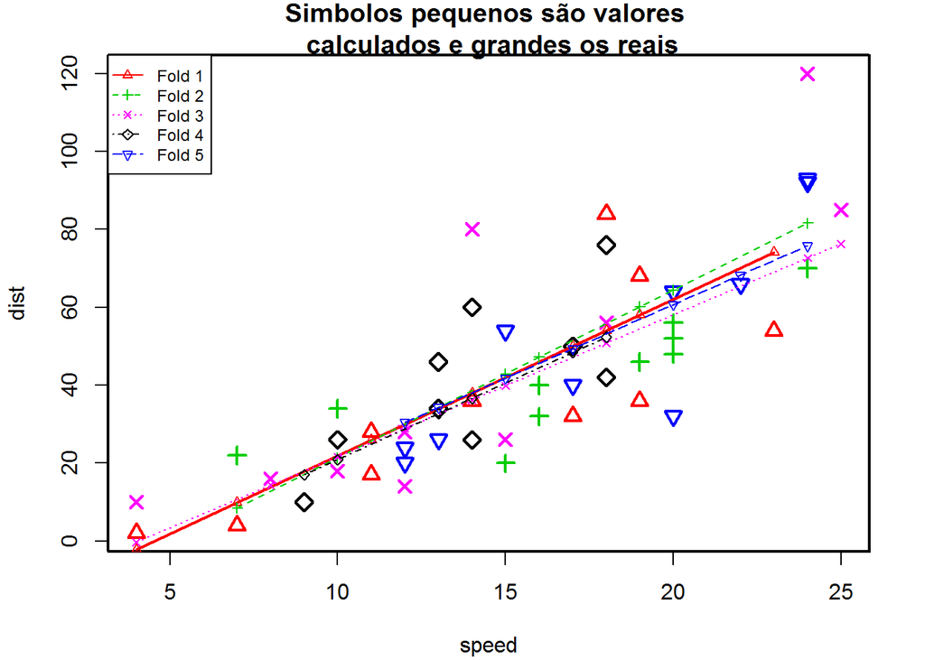

[output not shown]

Até aqui analisamos os conceitos básicos de regressão linear. Precisamos entender que a regressão linear é baseado em alguns presupostos e devemos ter cuidado especial quando temos diferentes variáveis explicativas.

FIM de Regressão linear

```r
save(list = ls(), file = "regressão_linear_all.Rdata")
```